# Labor Market

Session 2

Luis F. Gómez L.

luis.gomezl@unimilitar.edu.co

Distance Learning Faculty

12 February, 2026

# Please Read Me

- Check the message **Welcome greeting** published in Announcements forum.
- Dear student please edit your profile uploading a photo where your face is clearly visible.
- If you want to participate, please fill out the following survey: **Primer corte 30% > Learning Activities > Tu opinión sobre la economía colombiana**
- This presentation is based on (Cardenas, 2020, Chapter 9)
- **Purpose**
  - Examine the evolution and characteristics of the supply and demand of labor in Colombia

# Unemployment

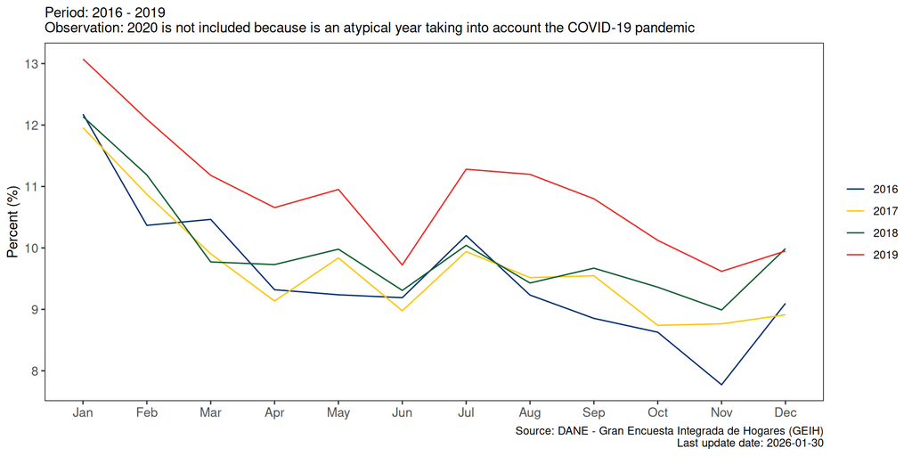

Figure 1: Behavior of unemployment rate in Colombia for selected years

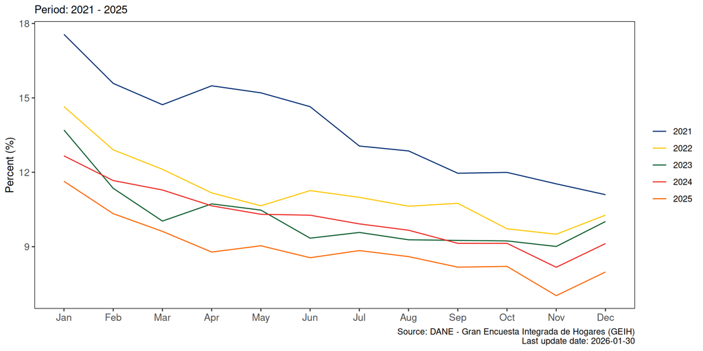

Figure 2: Behavior of unemployment rate in Colombia for selected years

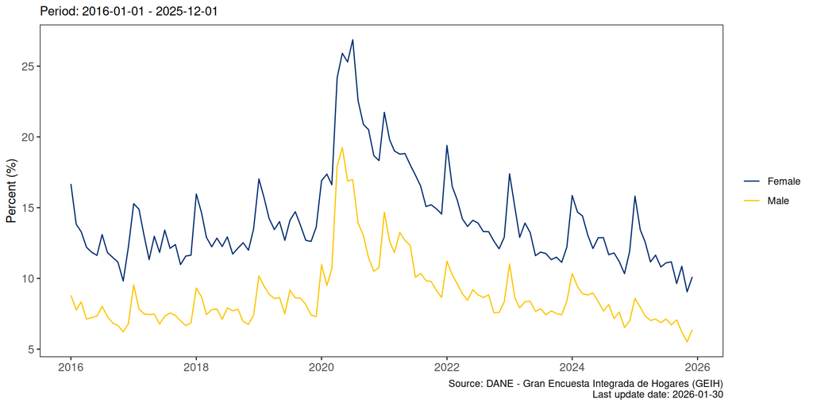

Figure 3: Unemployment rate in Colombia for men and women

# Employed

Table 1: Employed by sector in Colombia

| Concept | 2025 - December |
| --- | --- |
| Población ocupada Total nacional | 24223650 |
| Comercio y reparación de vehículos | 4261704 |
| Agricultura, ganadería, caza, silvicultura y pesca | 3108382 |
| Administración pública y defensa, educación y atención de la salud humana | 2899854 |
| Industrias manufactureras | 2884530 |
| Actividades artísticas, entretenimiento, recreación y otras actividades de servicios | 2119538 |
| Actividades profesionales, científicas, técnicas y servicios administrativos | 1915144 |
| Alojamiento y servicios de comida | 1895394 |
| Transporte y almacenamiento | 1733987 |
| Construcción | 1630402 |
| Suministro de electricidad, gas, agua y gestión de desechos^ | 608993 |
| Actividades financieras y de seguros | 418718 |
| Información y comunicaciones | 391190 |
| Actividades inmobiliarias | 355816 |
| No informa | 0 |

Source: DANE - Gran Encuesta Integrada de Hogares (GEIH)  
Last update date: 2026-01-30

Table 2: Employed by occupational position in Colombia

| Concept | 2025 - December |
| --- | --- |
| Población ocupada Total nacional | 24223650 |
| Obrero, empleado particular | 11063307 |
| Trabajador por cuenta propia | 9632546 |
| Obrero, empleado del gobierno | 925617 |
| Jornalero o Peón | 848610 |
| Empleado doméstico | 706177 |
| Patrón o empleador | 601238 |
| Trabajador familiar sin remuneración | 433807 |
| Otro | 12347 |

Source: DANE - Gran Encuesta Integrada de Hogares (GEIH)  
Last update date: 2026-01-30

# Informality

- What is informality?
  - The classification used in Colombia is based initially on the occupational position. For more information about definitions of the occupational position check out (DANE, 2024, pp. 88–92)
    - **Obrero, empleado del gobierno** is not considered informal in any case
    - **Obrero o empleado de empresa particular**, **Empleado doméstico** and **Trabajador sin remuneración en empresas o negocios de otros hogares** who do not have health or pension contributions made due to their employment relationship with the employer who hired them are considered informal
    - **Jornalero o Peón** and **Trabajador familiar sin remuneración** are considered informal
- What is informality?
  - The classification used in Colombia is based initially on the occupational position. For more information about definitions of the occupational position check out (DANE, 2024, pp. 88–92)
    - **Patrón o empleador** and **Trabajador por cuenta propia** classified as informal[^1]
    - Those employed in the sectors with ISIC codes 84 and 99 with the exception of **Jornalero o Peón** and **Trabajador familiar sin remuneración** are not considered informal
- Informality proportion (PI)
  - Employed (E)
  - Informal Employed (I)

$$PI = \frac{I}{E} \times 100$$

- Formality proportion (PF)

$$PF = 1- PI = 1 - \frac{I}{E} \times 100$$

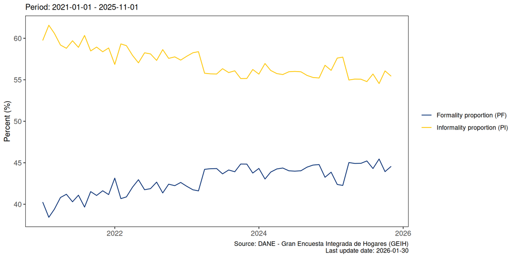

Figure 4: Formality and informality proportion in Colombia

# Informality proportion vs unemployment rate

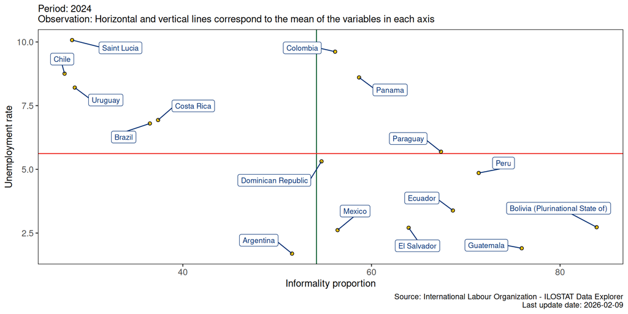

Figure 5: Informality proportion vs unemployment rate for some countries in Latin America

# The big picture and connecting ideas

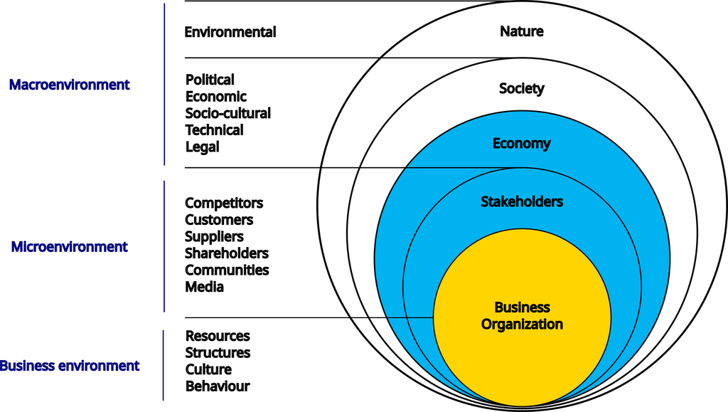

Figure 6: Macro, micro and organizational level business (Saukkonen & Kirjavainen, 2020)

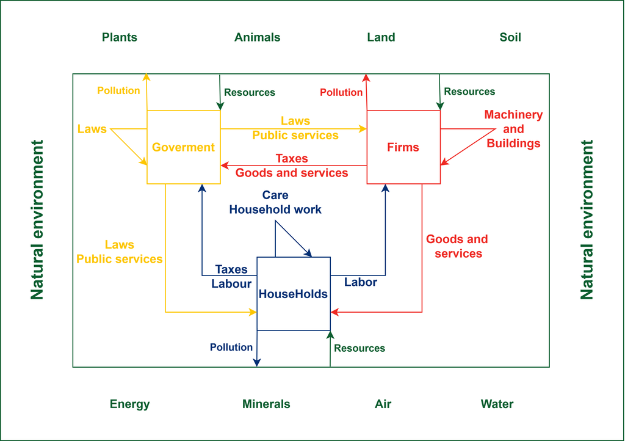

Figure 7: A model of the economy: flows of resources (Team, 2023, Chapter 1, sec. 1.13)

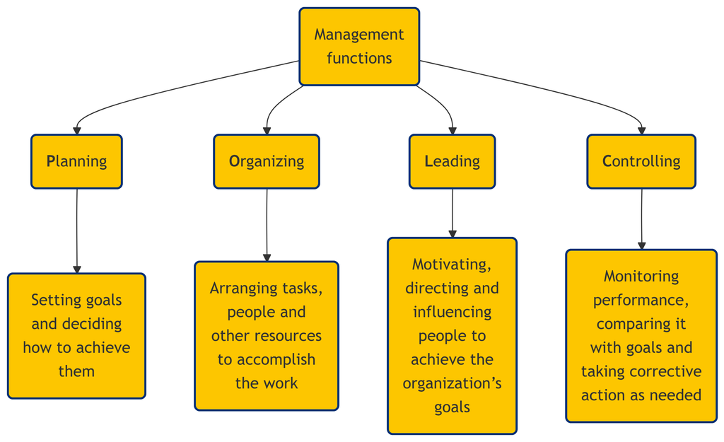

Figure 8: POLC framework (Kinicki & Soignet, 2022, pp. 8–10)

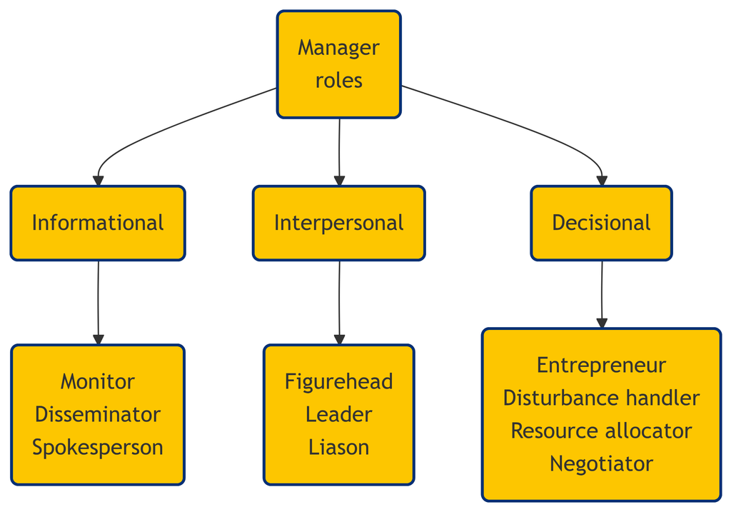

Figure 9: The roles managers play (Featured, 2019, Chapter 2, sec. 1.2)

# Acknowledgments

- To my family that supports me
- To the taxpayers of Colombia and the [**UMNG students**](https://www.umng.edu.co/estudiante) who pay my salary
- To the [**Business Science**](https://www.business-science.io/) and [**R4DS Online Learning**](https://www.rfordatasci.com/) communities where I learn [**R**](https://www.r-project.org/about.html) and [**$\pi$-thon**](https://www.python.org/about/)
- To the [**R Core Team**](https://www.r-project.org/contributors.html), the creators of [**RStudio IDE**](https://posit.co/download/rstudio-desktop/), [**Positron**](https://positron.posit.co/), [**Quarto**](https://quarto.org/) and the authors and maintainers of the packages [**tidyverse**](https://CRAN.R-project.org/package=tidyverse), [**readxl**](https://CRAN.R-project.org/package=readxl), [**gt**](https://CRAN.R-project.org/package=gt), [**janitor**](https://CRAN.R-project.org/package=janitor), [**Rilostat**](https://CRAN.R-project.org/package=Rilostat), [**ggrepel**](https://CRAN.R-project.org/package=ggrepel) and [**tinytex**](https://CRAN.R-project.org/package=tinytex) for allowing me to access these tools without paying for a license

# References

Cardenas, M. (2020). *Introducción a la Economía Colombiana* (4th ed.). Alfaomega.

DANE. (2024). *Manual de recolección y conceptos y básicos Grand Encuesta Integrada de Hogares*. Dirección de Metodología y Producción Estadística. https://microdatos.dane.gov.co/index.php/catalog/819/download/23312

Featured, O. (2019). *Principles of management* (1st ed.). OpenStax. https://openstax.org/details/books/principles-management

Kinicki, A., & Soignet, D. B. (2022). *Management: A practical introduction* (10th ed.). McGraw-Hill Education.

Saukkonen, N., & Kirjavainen, J. (2020). Business Environment: Emerging External and Internal Pressures for Sustainable Production. In W. Leal Filho, A. M. Azul, L. Brandli, P. G. Özuyar, & T. Wall (Eds.), *Responsible Consumption and Production* (pp. 37–48). Springer International Publishing. https://doi.org/10.1007/978-3-319-95726-5_1

Team, T. C. E. (2023). *The Economy 2.0: Microeconomics* (2nd ed.). https://core-econ.org/the-economy/

## Footnotes

[^1]: The rules are not simple in this case. Check https://www.dane.gov.co/index.php/estadisticas-por-tema/mercado-laboral/empleo-informal-y-seguridad-social > Anexos in relation to the sheets **Código_SAS** or **Código_STATA**